# 📈 Forecasting Food Retail Turnover in Western Australia

# 7 🦠COVID-19 Shock Analysis

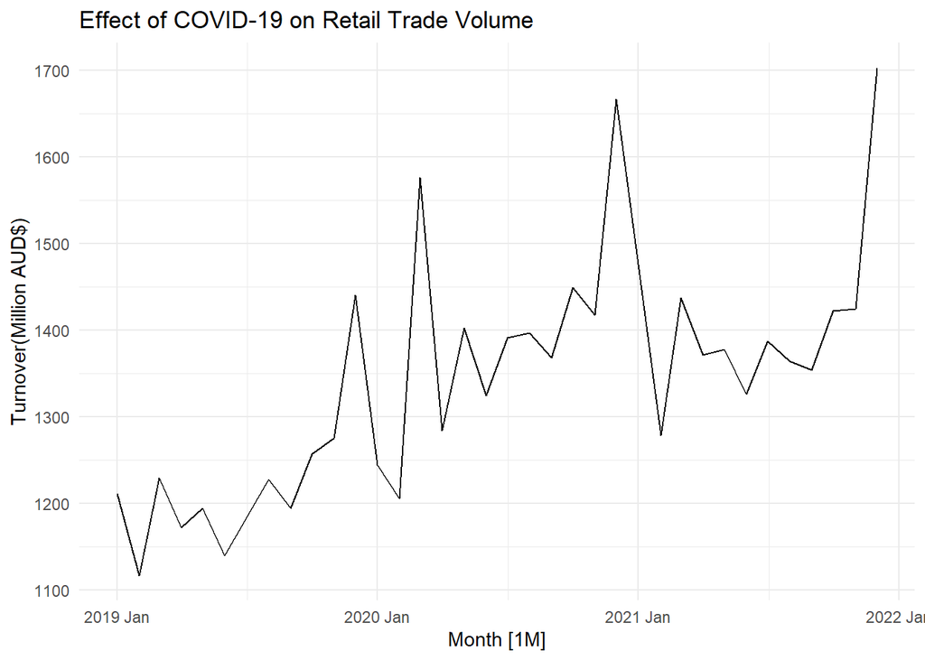

```r
# Plot focusing on the COVID-19 period using autoplot
period_covid <- retail %>%
  filter_index("2019 Jan" ~ "2021 Dec")

period_covid %>%
  autoplot(Turnover) +
  labs(title = "Effect of COVID-19 on Retail Trade Volume", y = "Turnover(Million AUD$)") +
  theme_minimal()
```

## 7.1 Effect of COVID-19

### 7.1.1 Visual Inspection:

- Observation: A detailed examination of the period from January 2019 to December 2021 reveals significant anomalies around the onset of the COVID-19 pandemic. The graph indicates notable disruptions in the trend and seasonal patterns of the retail trade volume.
- Graph: The included plot visually highlights the changes in turnover around the COVID-19 period, showing significant volatility and deviations from the expected trend.

### 7.1.2 Impact Analysis:

- Sharp Increases: There are notable sharp increases in turnover during early 2020. This is likely due to panic buying and stockpiling as consumers reacted to the uncertainty and potential shortages caused by the pandemic.
- Fluctuations: The turnover exhibits subsequent fluctuations throughout 2020 and 2021. These fluctuations reflect the effects of lockdowns, restrictions, and changing consumer behavior as the situation evolved.
- Statistical Shifts: The series shows significant shifts in level and variability, highlighting the pandemic’s impact on retail trade volume. These shifts are evidenced by increased volatility and changes in the turnover’s level during the pandemic period.

In summery, The impact of COVID-19 introduced considerable volatility and disrupted typical seasonal patterns. These effects must be accounted for in the forecasting models to ensure accuracy. Understanding these disruptions is crucial for developing reliable forecasts and making informed business decisions.

These observations provide a comprehensive understanding of the data’s characteristics, which are crucial for developing accurate forecasting models.